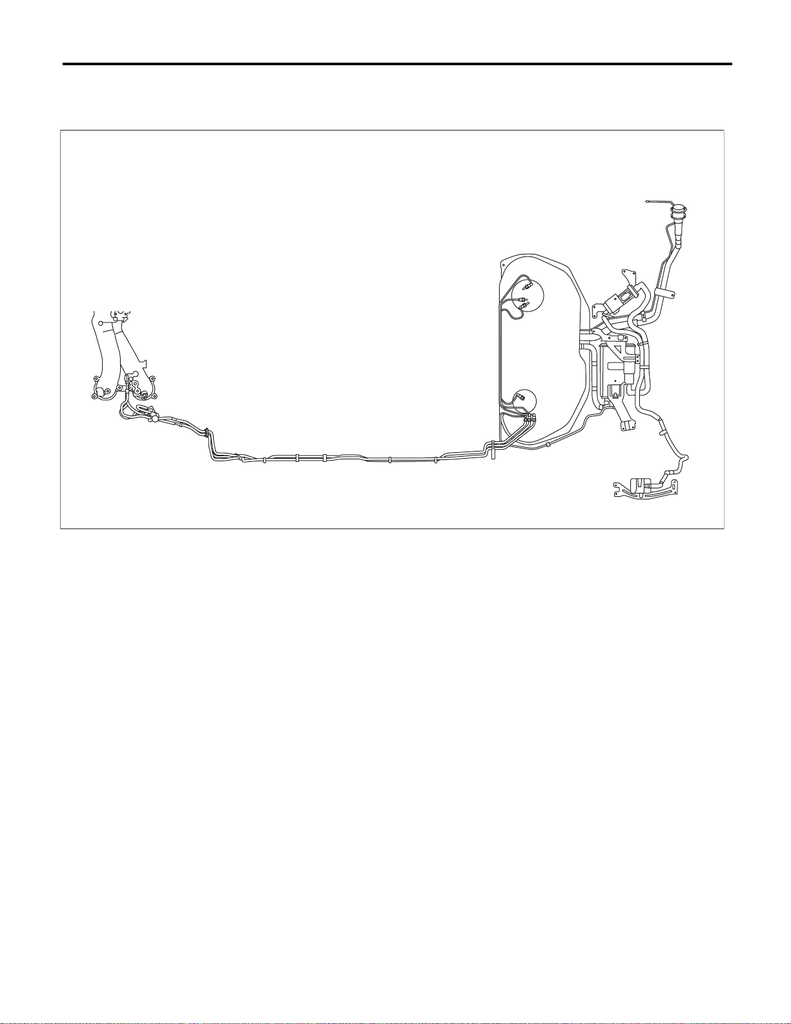

FU(STI)-94

Fuel Delivery, Return and Evaporation Lines

FUEL INJECTION (FUEL SYSTEMS)

35.Fuel Delivery, Return and Evaporation Lines

A: REMOVAL

WARNING:

Place “NO OPEN FLAMES” signs near the working area.

CAUTION:

Be careful not to spill fuel.

1) Release the fuel pressure. <Ref. to FU(STI)-64, RELEASING OF FUEL PRESSURE, PROCEDURE, Fu-

el.>

2) Open the fuel filler lid and remove the fuel filler cap.

NOTE:

This operation is required to release the inner pressure of the fuel tank.

3) Remove the floor mat. <Ref. to EI-105, REMOVAL, Floor Mat.>

FU-08305

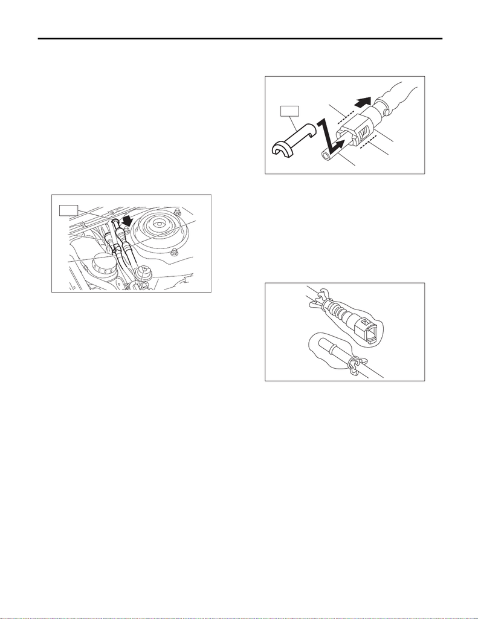

FU(STI)-95

Fuel Delivery, Return and Evaporation Lines

FUEL INJECTION (FUEL SYSTEMS)

4) In the engine compartment, disconnect the fuel

delivery hoses, fuel return hoses and evaporation

hoses.

CAUTION:

• Be careful not to spill fuel.

• Catch the fuel from hoses using a container

or cloth.

(1) Set the ST to the fuel pipe.

ST 42099AE000 QUICK CONNECTOR RE-

LEASE

(2) Disconnect the quick connector of the fuel

delivery hose and fuel return hose by pushing

the ST in the direction of the arrow.

(3) Remove the clip and disconnect the evapo-

ration hose from the fuel pipe.

5) Remove the fuel tank. <Ref. to FU(STI)-67, RE-

MOVAL, Fuel Tank.>

6) Disconnect the quick connector, and remove the

fuel delivery tube, fuel return tube, and jet pump

tube from the fuel tank.

• When using ST

1. Attach ST to the pipe and push ST in the direc-

tion of arrow mark to disconnect the quick connec-

tor.

ST 42099AE000 QUICK CONNECTOR RE-

LEASE

CAUTION:

• Be careful not to spill fuel.

• Catch the fuel from the tubes using a con-

tainer or cloth.

• To disconnect the connector, hold (C)

shown in the figure and pull in axial direction.

• If the connector and pipe are sticking to

each other, push and pull the connector with

ST pushed, and then pull the connector after

it starts moving freely.

• When disconnecting the connector, do not

bend or twist the tube forcibly. If the tube is

bent, replace with a new part.

NOTE:

Clean the pipe and quick connector, if they are cov-

ered with dust.

2. To prevent from damaging or entering foreign

matter, wrap the pipes and quick connectors with

plastic bag etc.

CAUTION:

When reusing the retainer, do not disconnect

the retainer from the connector.

(A) Fuel delivery hose

(B) Fuel return hose

(C) Evaporation hose

FU-08428

ST

(A)

(B)

(C)

(A) Quick connector

(B) Pipe

(C) Connector holding position

FU-05506

ST

(A)

(B)

(C)

(C)

FU-01333

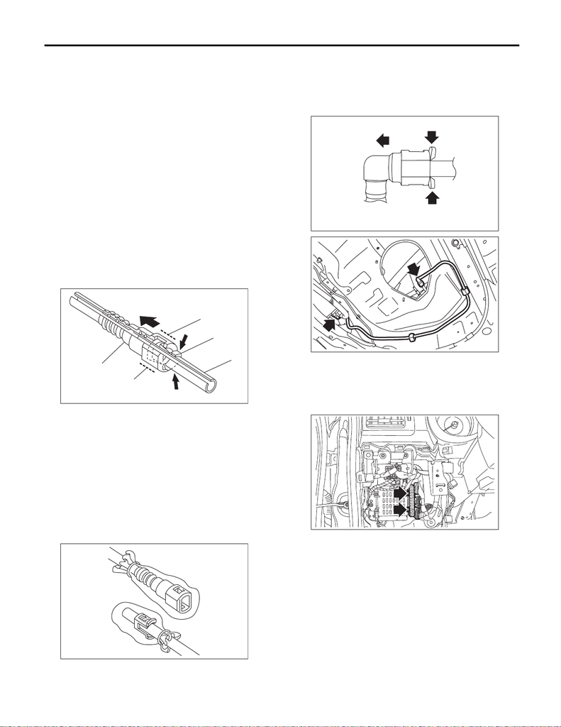

FU(STI)-96

Fuel Delivery, Return and Evaporation Lines

FUEL INJECTION (FUEL SYSTEMS)

• When not using ST

1. Push the retainer in the direction of the arrow,

disconnect the quick connector from pipe.

CAUTION:

• Be careful not to spill fuel.

• Catch the fuel from the tubes using a con-

tainer or cloth.

• To disconnect the connector, hold (D)

shown in the figure and pull in axial direction.

• If the connector and pipe are sticking to

each other, push and pull the connector with

the retainer pushed in the direction of the ar-

row, and then pull the connector after it starts

moving freely.

• When disconnecting the connector, do not

bend or twist the tube forcibly. If the tube is

bent, replace with a new part.

NOTE:

Clean the pipe and quick connector, if they are cov-

ered with dust.

2. To prevent from damaging or entering foreign

matter, wrap the pipes and quick connectors with

plastic bag etc.

CAUTION:

When reusing the retainer, do not disconnect

the retainer from the pipe.

7) Disconnect the quick connector and remove the

purge pipe.

NOTE:

Disconnect the quick connector as shown in the fig-

ure.

8) Remove the body integrated unit.

(1) Remove the knee airbag module. <Ref. to

AB-35, REMOVAL, Knee Airbag Module.>

(2) Release the lock and remove the fuse hold-

er from the relay & fuse box.

(3) Disconnect the connectors from the relay &

fuse box.

(A) Quick connector

(B) Retainer

(C) Pipe

(D) Connector holding position

FU-05510

(A)

(B)

(C)

(D)

(D)

FU-05507

FU-08359

1

1

2

FU-08358

FU-08351

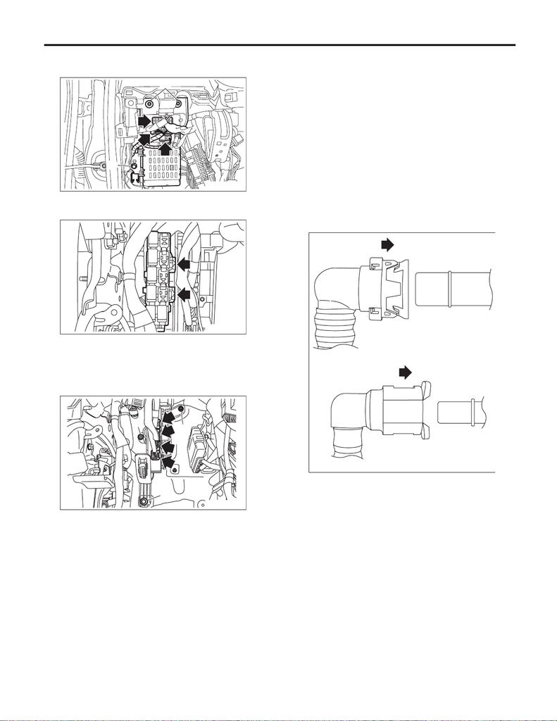

FU(STI)-97

Fuel Delivery, Return and Evaporation Lines

FUEL INJECTION (FUEL SYSTEMS)

(4) Remove the bolts (A) and nuts (B), and re-

move the relay & fuse box.

(5) Release the lock and remove the relay

block.

(6) Disconnect the connector from body inte-

grated unit.

(7) Remove the bolt (A) and nut (B), and re-

move the body integrated unit along with the

bracket.

9) Remove the fuel pipe assembly from vehicle.

B: INSTALLATION

Install in the reverse order of removal while being

careful of the following.

1. CONNECTING THE EVAPORATION LINE

QUICK CONNECTOR

NOTE:

Connect the quick connector as shown in the fig-

ure.

CAUTION:

• Check that there is no damage or dust on the

quick connector. If necessary, clean the seal

surface of the pipe.

• Make sure that the quick connector is secure-

ly connected.

FU-08352

(A)

(B)

FU-08353

FU-08354

(B)

(B)

(A)

FU-05035

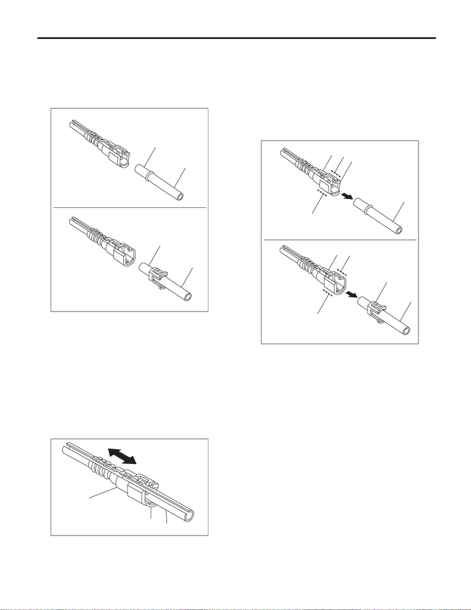

FU(STI)-98

Fuel Delivery, Return and Evaporation Lines

FUEL INJECTION (FUEL SYSTEMS)

2. CONNECTING THE FUEL LINE QUICK

CONNECTOR

CAUTION:

• Make sure there are no damage or dust on

connections. If necessary, clean seal surface of

pipe.

• When reusing the retainer, make sure that

neither scratches nor deformation exist on the

retainer. If it is faulty, use a new part.

1) Connect the quick connector to pipe.

CAUTION:

• Make sure that the quick connector is secure-

ly connected.

• Make sure the two retainer pawls are en-

gaged in their mating positions in the quick

connector.

• Be sure to inspect tubes and their connec-

tions for any leakage of fuel.

• To connect the connector, hold (d) shown in

the figure and push in axial direction.

• When connecting the connector, do not bend

or twist the tube forcibly. If the tube is bent, re-

place with a new part.

(A) When removed using the ST

(B) When removed without using the ST

(a) Seal surface

(b) Pipe

(A) Quick connector

(B) Retainer

(C) Pipe

FU-05508

(a)

(b)

(a)

(b)

(A)

(B)

FU-05511

(A)

(B)

(C)

(A) When removed using the ST

(B) When removed without using the ST

(a) Quick connector

(b) Retainer

(c) Pipe

(d) Connector holding position

FU-05509

(b)

(c)

(b)

(c)

(A)

(B)

(a)

(a)

(d)

(d)

(d)

(d)

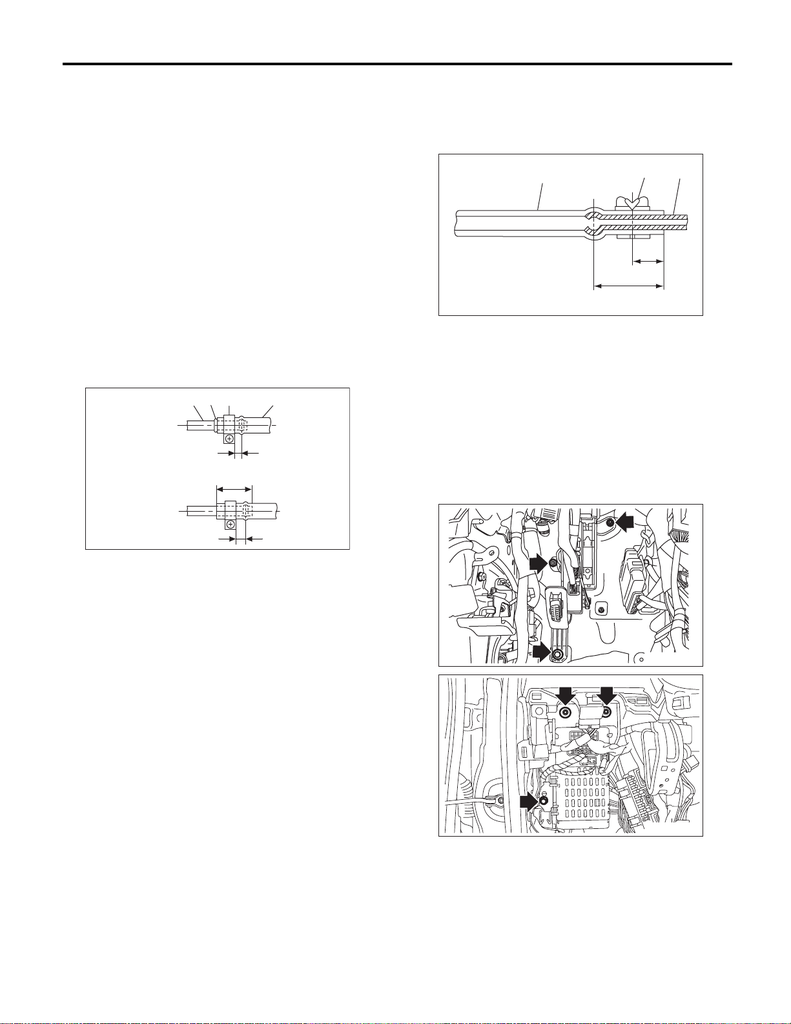

FU(STI)-99

Fuel Delivery, Return and Evaporation Lines

FUEL INJECTION (FUEL SYSTEMS)

3. CONNECTING FUEL DELIVERY HOSE,

FUEL RETURN HOSE AND FUEL HOSE

Connect the fuel delivery hose, fuel return hose,

and fuel hose as shown in the figure.

CAUTION:

• If the connection portion has a spool or stop-

per, do not allow the end of the hose to bend or

ride over by inserting the hose too deep.

• Be sure to inspect hoses and their connec-

tions for any leakage of fuel.

NOTE:

Use new fuel delivery hose, fuel return hose, and

fuel hose.

Tightening torque:

1.25 N·m (0.1 kgf-m, 0.9 ft-lb)

L1: 2.5

±

1.5 mm (0.098

±

0.059 in)

L2: 22.5

±

2.5 mm (0.886

±

0.098 in)

4. EVAPORATION HOSE CONNECTION

Connect the evaporation hose to the pipe with an

overlap of 15 to 20 mm (0.59 to 0.79 in).

L = 17.5

±

2.5 mm (0.689

±

0.098 in)

5. BODY INTEGRATED UNIT INSTALLA-

TION

Tighten the bolts and nuts in the figure to the torque

specified below.

Tightening torque:

7.5 N·m (0.8 kgf-m, 5.5 ft-lb)

C: INSPECTION

1) Check that the fuel pipe has no deformation,

cracks or other damages.

2) Check that the hose and tube have no cracks,

damage or loose part.

(1) When there is a spool or bump

(2) When there is no spool or bump

(3) Pipe

(4) Spool or bump

(5) Clamp

(6) Hose

FU-04503

(3)

(5)

(6)

L2

(1)

(2)

L1

L1

(4)

(1) Hose

(2) Clip

(3) Pipe

FU-04501

(1)

(2)

L/2

L

(3)

FU-08356

FU-08357